[O’Hara on GitHub](https://github.com/oharac)

# Map impacts per taxon

Compiled on Sat May 2 17:03:57 2020 by ohara

```r
library(raster)
source('https://raw.githubusercontent.com/oharac/src/master/R/common.R')

source(here('common_fxns.R'))
```

# 1 Summary

Create taxa-level maps of number of species impacted per cell, per year.

# 2 Methods

- Gather species maps by taxonomic group (IUCN comprehensively assessed groups)
- read in all impact maps for species for all years, flatten to impacted/not for each year
- add maps together for a taxa-level map for each year of number of impacted species per cell
- repeat similar process for refugia.

## 2.1 Match threatened species to taxonomic groups per IUCN

Identify the species included in the impacted list (using the IUCN species IDs of impact map files, from prior scripts!). Join this with the list of mapped species, to identify which taxonomic group the species is in (based on the downloaded IUCN shapefiles). Taxa groups not represented in the impacted species list will be dropped.

Taxonomic groups dropped from this analysis - i.e., group does not have any species that fits the “impacted” criteria:

chameleons, cycads, magnolias, fw_caridean_shrimps, fw_crayfish, conifers, surgeonfishes, crocodiles_and_alligators, fw_crabs, cacti, tarpons_and_ladyfishes, sturgeons, lobsters, amphibians

The one vulnerable tarpon species (i.e. not LC, EX, or DD) is not sensitive to any of the stressors and is not mapped, so the whole taxon is dropped from this analysis.

## 2.2 Loop over taxonomic groups to create taxa-level impact maps

These maps ignore the number of impacts occurring on each species, and count up the number of species impacted by the aggregated stressor group (land-based, ocean, climate, and fishing).

We will also map species impacts using the priority weights from script 3b, i.e.
$$\text{priority} = \frac{\text{% range impacted}}{\ln (\text{spp range, km}^2)}$$
Note that priority is based on mean impact over last three impacted years.

For a given taxon:

- identify full list of impacted species
- select a subgroup (~10 spp) to process at a time
  - read in all spp in group
  - flatten all spp impact maps (for impacts > 0, set “impacted” = TRUE)
    - no need to worry about refugia cells at this stage.
  - add all maps for this group: by cell/year per stressor
  - also add priority values for each cell/year per stressor
- for all subgroups in a taxa, add them up.

## 2.3 Animate select taxa impact maps

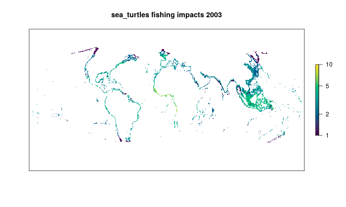

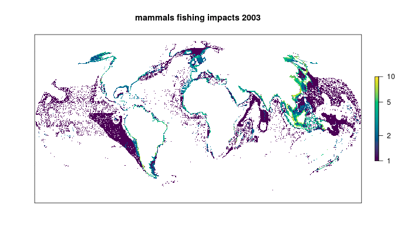

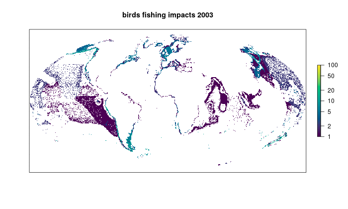

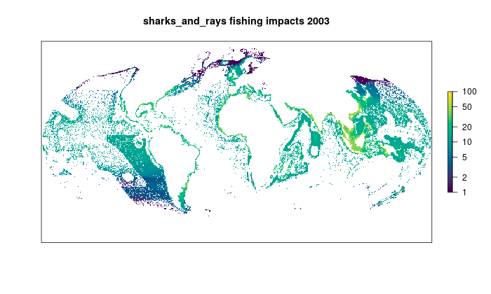

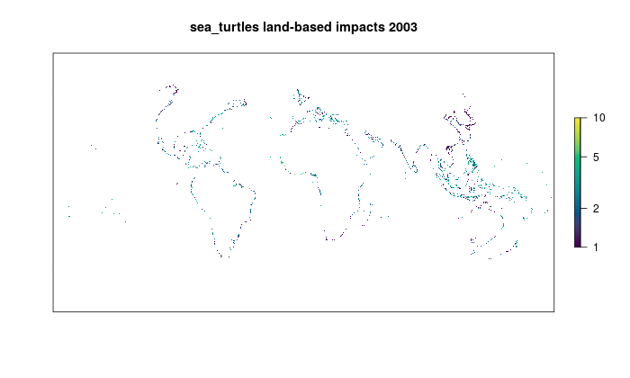

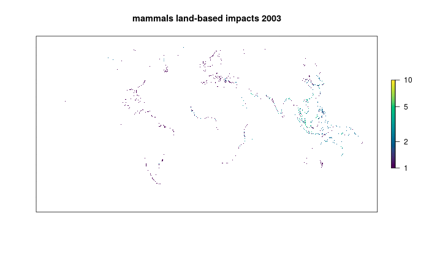

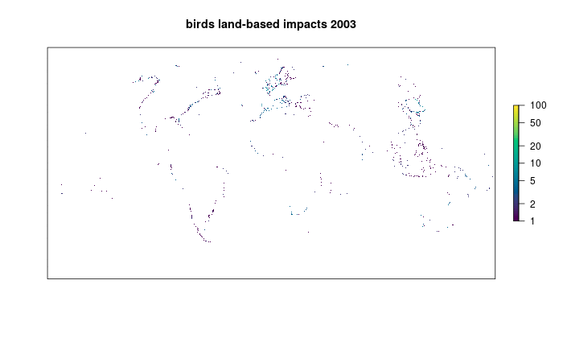

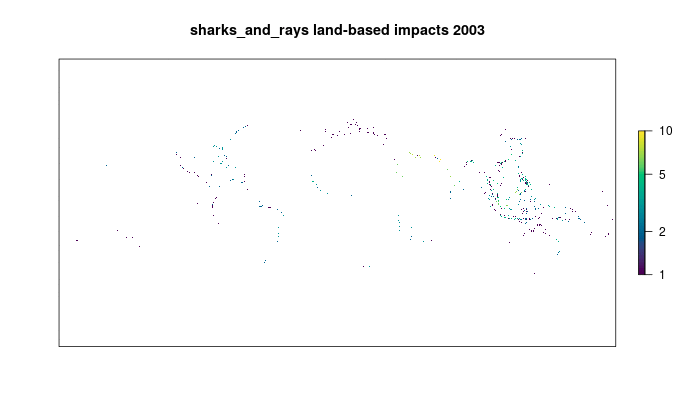

[figure not shown]

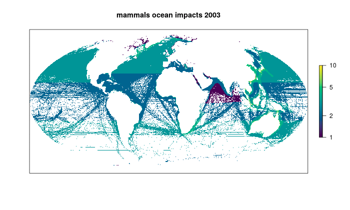

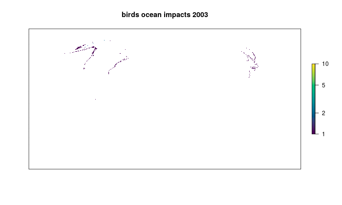

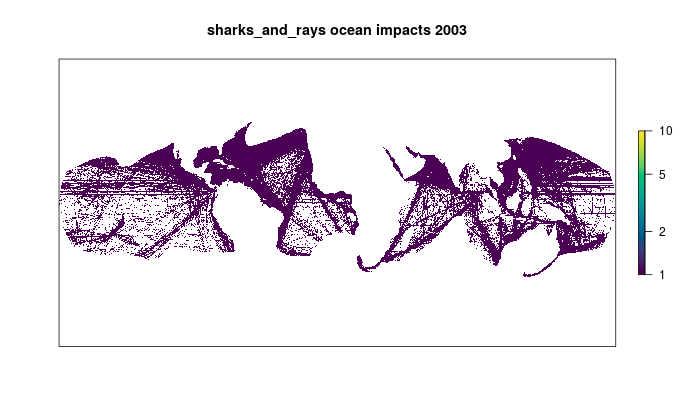

[5 more figures not shown]

## 2.4 Animate count vs. priority maps

Just for the most recent year of each, back and forth to highlight diffs. To highlight the differences in *pattern* not *magnitude*, I’ll stretch the priority scale to have the same range as the count scale (i.e. 1 to the max number of critters).

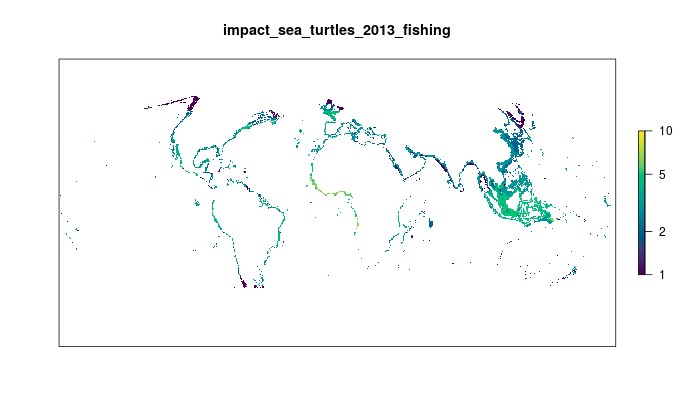

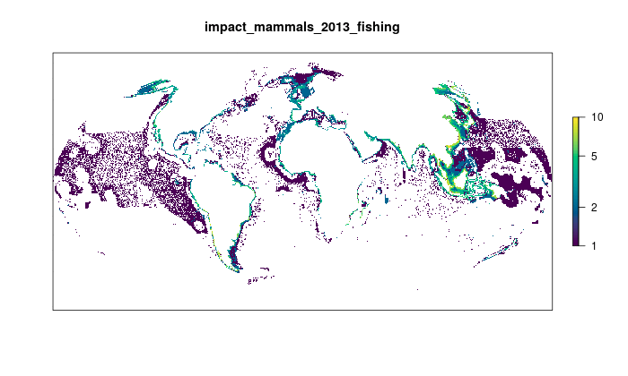

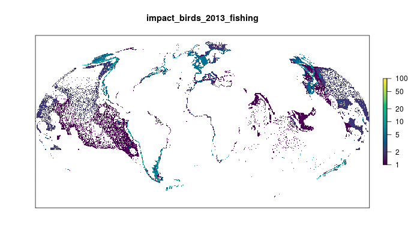

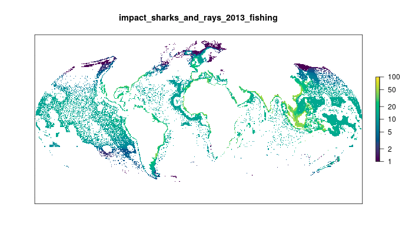

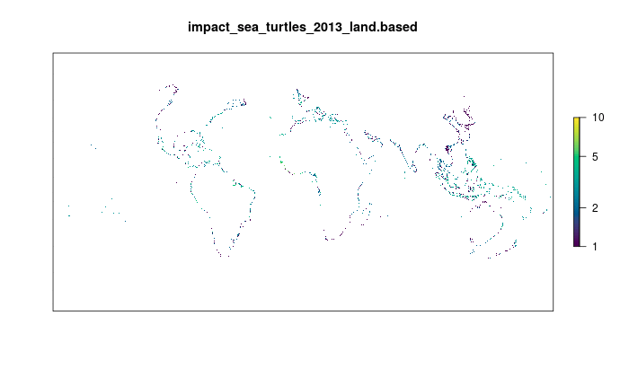

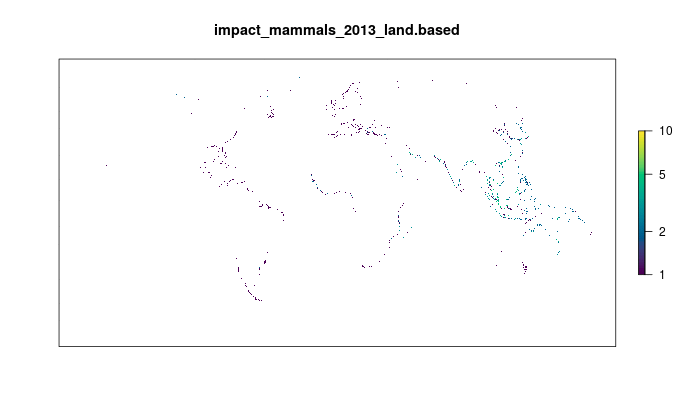

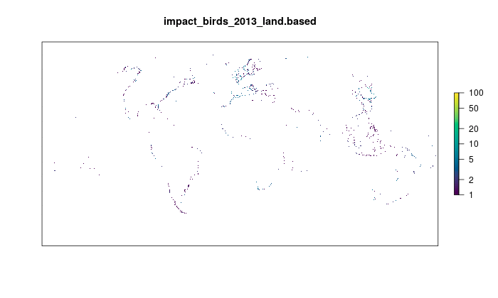

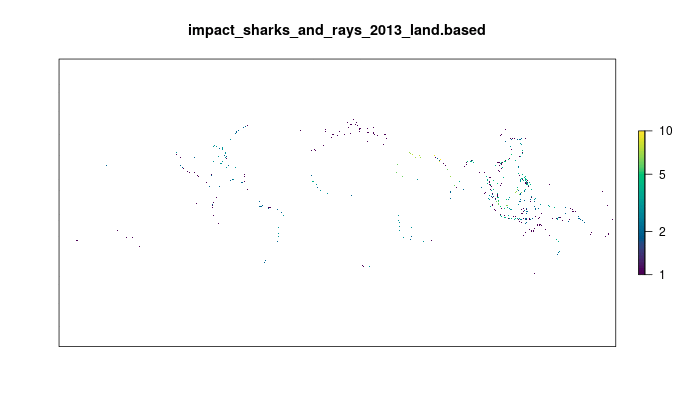

[figure not shown]

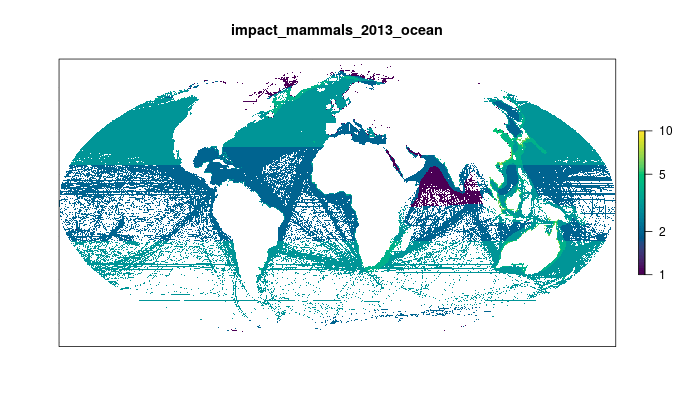

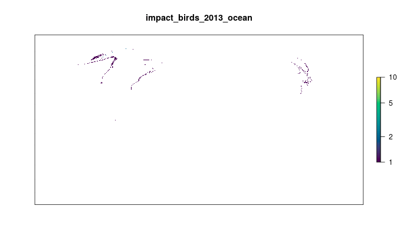

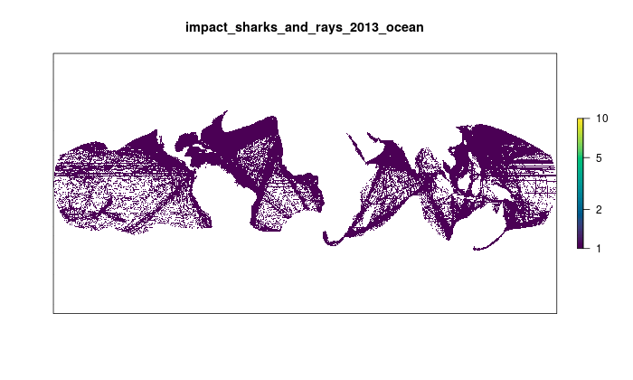

[4 more figures not shown]